# Reproducible Research - Peer Assignment 1

O.D.

Thursday, February 15, 2015

Here are the results for the first Peer Assignment of the Coursera Data Science Module: Reproducible Research.

# Loading and preprocessing the data

```r
require(dplyr)
```

```r
require(ggplot2)
temp <- tempfile()
act <- read.csv("activity.csv", header=T)
act[,2] <- as.Date(act[,2])
act <- tbl_df(act)
```

# What is mean total number of steps taken per day?

1. Calculate the total number of steps taken per day

```r
act_by_day <- act %>%
        group_by(date) %>%
        summarize(total_steps = sum(steps))

head(act_by_day, 20)
```

```
## Source: local data frame [20 x 2]
##
##          date total_steps
## 1  2012-10-01          NA
## 2  2012-10-02         126
## 3  2012-10-03       11352
## 4  2012-10-04       12116
## 5  2012-10-05       13294
## 6  2012-10-06       15420
## 7  2012-10-07       11015
## 8  2012-10-08          NA
## 9  2012-10-09       12811
## 10 2012-10-10        9900
## 11 2012-10-11       10304
## 12 2012-10-12       17382
## 13 2012-10-13       12426
## 14 2012-10-14       15098
## 15 2012-10-15       10139
## 16 2012-10-16       15084
## 17 2012-10-17       13452
## 18 2012-10-18       10056
## 19 2012-10-19       11829
## 20 2012-10-20       10395
```

2. Make a histogram of the total number of steps taken each day

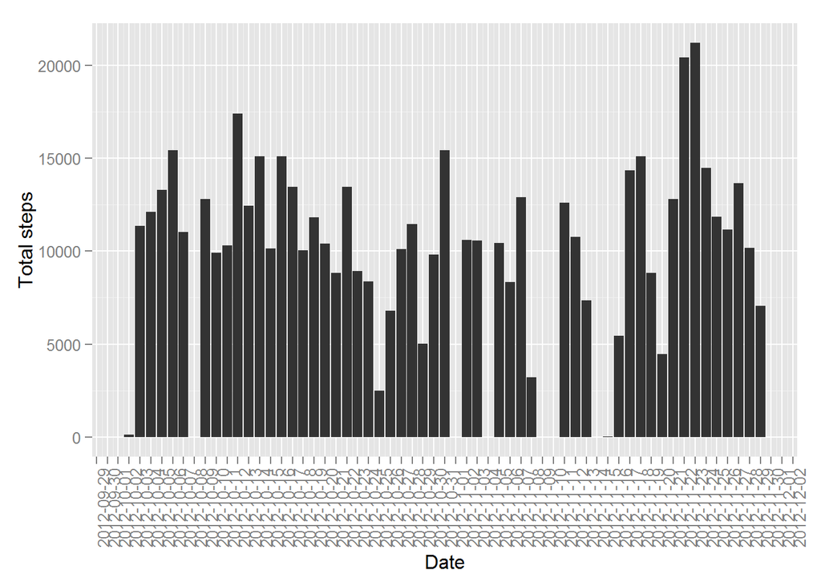

```r
ggplot(act_by_day, aes(x=date, y=total_steps) ) + geom_bar(stat="identity") + scale_x_date(breaks = "1 day") + xlab("Date") + ylab("Total steps") + theme(axis.text.x = element_text(angle = 90, hjust = 1))
```

3. Calculate and report the mean and median of the total number of steps taken per day

```r
summarize(act_by_day, Mean = mean(total_steps, na.rm = T), Median = median(total_steps, na.rm = T))
```

```
## Source: local data frame [1 x 2]
##
##       Mean Median
## 1 10766.19  10765
```

# What is the average daily activity pattern?

1. Make a time series plot (i.e. type = “l”) of the 5-minute interval (x-axis) and the average number of steps taken, averaged across all days (y-axis)

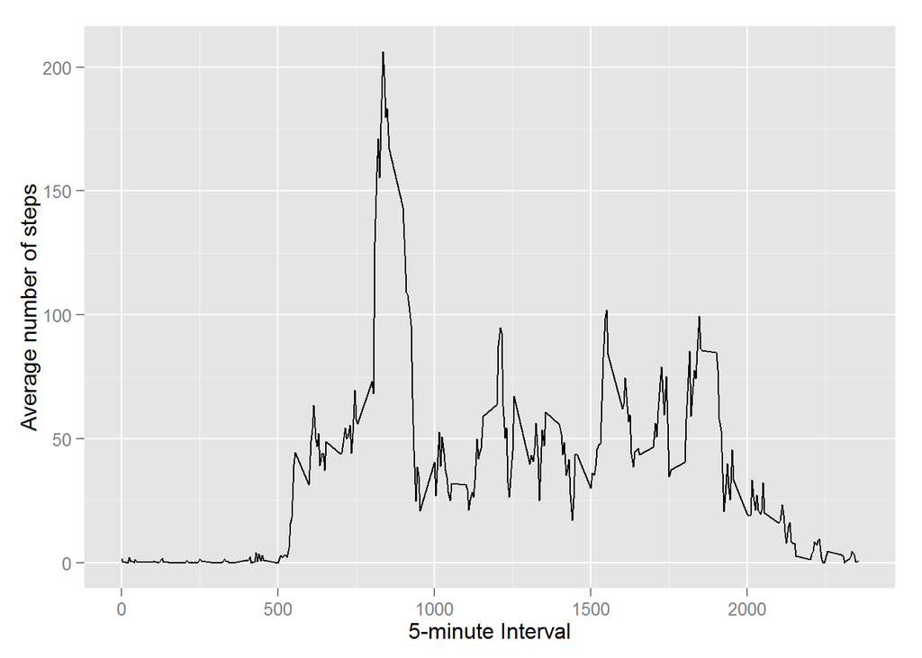

```r
avg_steps <- act %>%
        group_by(interval) %>%
        summarize(ave_steps = mean(steps, na.rm = T))

ggplot(avg_steps, aes(interval, ave_steps)) + geom_line() +
   xlab("5-minute Interval") + ylab("Average number of steps")
```

2. Which 5-minute interval, on average across all the days in the dataset, contains the maximum number of steps?

```r
act_max_steps <- act %>%
        group_by(date) %>%
        summarize(max_steps = max(steps))
act_max_steps <- merge(act_max_steps, act, by="date")
act_max_steps <- act_max_steps %>%
        filter(steps == max_steps) %>%
        select(date, max_steps, interval)
act_max_steps %>%
        slice(which.max(max_steps)) %>%
        select(interval)
```

[output not shown]

# Imputing missing values

1. Calculate and report the total number of missing values in the dataset (i.e. the total number of rows with NAs)

```r
table(is.na(act))
```

```
##
## FALSE  TRUE
## 50400  2304
```

2. Devise a strategy for filling in all of the missing values in the dataset. The strategy does not need to be sophisticated. For example, you could use the mean/median for that day, or the mean for that 5-minute interval, etc.

```r
act <- act %>%
        group_by(interval) %>%
        mutate(steps_mean_int = mean(steps, na.rm = T))

for(i in 1:nrow(act)){
        if(is.na(act[i,1]) == TRUE){
                act[i,1] <- act[i,4] # If NA, set to mean of corresponding 5-minute interval.
        }
}
```

3. Create a new dataset that is equal to the original dataset but with the missing data filled in.

```r
act_new <- act[,-4] # remove the "mean of steps per interval" column
head(act_new, 20)
```

```
## Source: local data frame [20 x 3]
## Groups: interval
##
##        steps       date interval
## 1  1.7169811 2012-10-01        0
## 2  0.3396226 2012-10-01        5
## 3  0.1320755 2012-10-01       10
## 4  0.1509434 2012-10-01       15
## 5  0.0754717 2012-10-01       20
## 6  2.0943396 2012-10-01       25
## 7  0.5283019 2012-10-01       30
## 8  0.8679245 2012-10-01       35
## 9  0.0000000 2012-10-01       40
## 10 1.4716981 2012-10-01       45
## 11 0.3018868 2012-10-01       50
## 12 0.1320755 2012-10-01       55
## 13 0.3207547 2012-10-01      100
## 14 0.6792453 2012-10-01      105
## 15 0.1509434 2012-10-01      110
## 16 0.3396226 2012-10-01      115
## 17 0.0000000 2012-10-01      120
## 18 1.1132075 2012-10-01      125
## 19 1.8301887 2012-10-01      130
## 20 0.1698113 2012-10-01      135
```

4. Make a histogram of the total number of steps taken each day and Calculate and report the mean and median total number of steps taken per day. Do these values differ from the estimates from the first part of the assignment? What is the impact of imputing missing data on the estimates of the total daily number of steps?

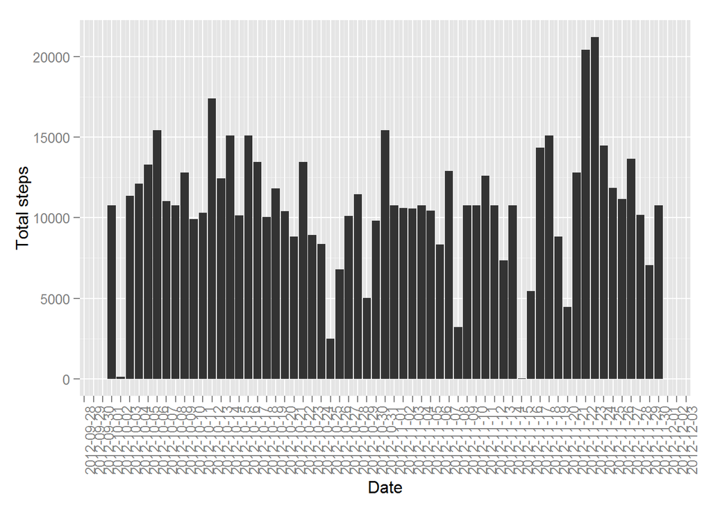

```r
act_by_day_new <- act_new %>%
        group_by(date) %>%
        summarize(total_steps = sum(steps))

ggplot(act_by_day_new, aes(x=date, y=total_steps) ) + geom_bar(stat="identity") + scale_x_date(breaks = "1 day") + xlab("Date") + ylab("Total steps") + theme(axis.text.x = element_text(angle = 90, hjust = 1))
```

```r
summarize(act_by_day_new, Mean = mean(total_steps, na.rm = T), Median = median(total_steps, na.rm = T))
```

```
## Source: local data frame [1 x 2]
##
##       Mean   Median
## 1 10766.19 10766.19
```

Because we took the mean of the steps for each interval as a replacement for the NAs the difference between both parts of the assignments in the end result is almost non-existent. Naturally, the median differs slightly (by 1). Imputing missing data with other values than the mean would result in more significant differences.

# Are there differences in activity patterns between weekdays and weekends?

1. Create a new factor variable in the dataset with two levels – “weekday” and “weekend” indicating whether a given date is a weekday or weekend day.

```r
Sys.setlocale("LC_TIME", "English")
```

```
## [1] "English_United States.1252"
```

```r
day <- weekdays(act_new$date)
day_type <- vector()
for(i in 1:nrow(act_new)) {
    if(day[i] == "Saturday" | day[i] == "Sunday"){
        day_type[i] <- "Weekend"
    }else{
        day_type[i] <- "Weekday"
    }
}
act_new$day_type <- day_type
act_new$day_type <- factor(act_new$day_type)
summary(act_new$day_type)
```

```
## Weekday Weekend
##   12960    4608
```

2. Make a panel plot containing a time series plot (i.e. type = “l”) of the 5-minute interval (x-axis) and the average number of steps taken, averaged across all weekday days or weekend days (y-axis). See the README file in the GitHub repository to see an example of what this plot should look like using simulated data.

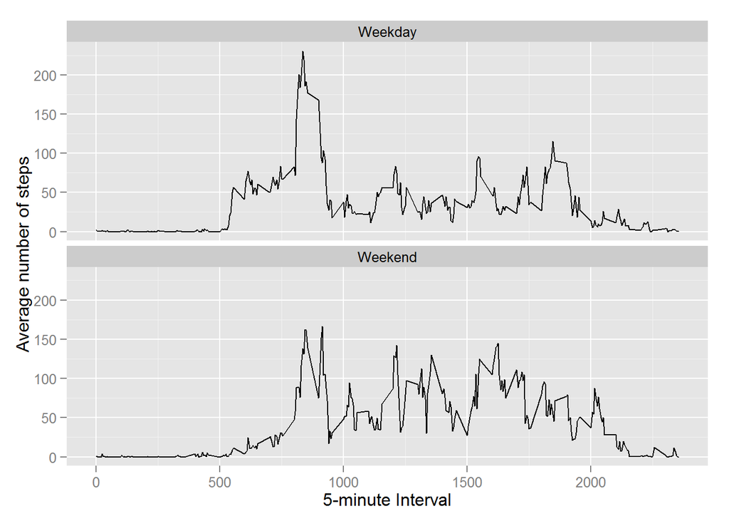

```r
act_new <- act_new %>%
        group_by(interval, day_type) %>%
        mutate(avg_steps = mean(steps))

ggplot(act_new, aes(interval, avg_steps)) + geom_line() +
   xlab("5-minute Interval") + ylab("Average number of steps") + facet_wrap(~ day_type, ncol=1)
```

Done!